# Assignment 2

STATS 369

Rudklao Raviyan UPI:rrav628, ID: 2590622

*It is good practice to have all your general set up at the start of your document. Imagine this is the beginning of a new Rmd. This is where I would set any general chunk options, as well as where I would load my libraries. If I realise I need additional libraries later, I would come back here and add them.*

*Notes from me are in italics.*

```r
# Set code to show
knitr::opts_chunk$set(echo = TRUE)

# Load libraries
library(tidyverse)
library(purrr)
library(leaps)
library(ggplot2)
library(reshape)
library(boot)
```

# Task 1.1

*Data obtained from Pandya, M (2022).*

```r
# read data using map()

getwd()

data_path <- "D:/Documents/Uni_UoA/Stats 369/Assignments/Assignment-2/a2_data"

data_files <- list.files(path = data_path, pattern = "*csv", full.names = TRUE)
import_data <- map(data_files, read_csv, show_col_types = F) %>%
  bind_rows()

write_csv(import_data, "data.csv")
```

## Requirememt 6

```r
data <- read_csv("D:/Documents/Uni_UoA/Stats 369/Assignments/Assignment-2/data.csv", show_col_types = F)

head(data,15)
```

```
## # A tibble: 15 × 20
##    track_id        artists album_name track_name popularity duration_ms explicit
##    <chr>           <chr>   <chr>      <chr>           <dbl>       <dbl> <lgl>
##  1 5SuOikwiRyPMVo… Gen Ho… Comedy     Comedy             73      230666 FALSE
##  2 4qPNDBW1i3p13q… Ben Wo… Ghost (Ac… Ghost - A…         55      149610 FALSE
##  3 1iJBSr7s7jYXzM… Ingrid… To Begin … To Begin …         57      210826 FALSE
##  4 6lfxq3CG4xtTiE… Kina G… Crazy Ric… Can't Hel…         71      201933 FALSE
##  5 5vjLSffimiIP26… Chord … Hold On    Hold On            82      198853 FALSE
##  6 01MVOl9KtVTNfF… Tyrone… Days I Wi… Days I Wi…         58      214240 FALSE
##  7 6Vc5wAMmXdKIAM… A Grea… Is There … Say Somet…         74      229400 FALSE
##  8 1EzrEOXmMH3G43… Jason … We Sing. … I'm Yours          80      242946 FALSE
##  9 0IktbUcnAGrvD0… Jason … We Sing. … Lucky              74      189613 FALSE
## 10 7k9GuJYLp2Azqo… Ross C… Hunger     Hunger             56      205594 FALSE
## 11 4mzP5mHkRvGxdh… Zack T… Episode    Give Me Y…         74      244800 FALSE
## 12 5ivF4eQBqJiVL5… Jason … Love Is a… I Won't G…         69      240165 FALSE
## 13 4ptDJbJl35d7gQ… Dan Be… Solo       Solo               52      198712 FALSE
## 14 0X9MxHR1rTkEHD… Anna H… Bad Liar   Bad Liar           62      248448 FALSE
## 15 4LbWtBkN82ZRhz… Chord … Hold On (… Hold On -…         56      188133 FALSE
## # ℹ 13 more variables: danceability <dbl>, energy <dbl>, key <dbl>,
## #   loudness <dbl>, mode <dbl>, speechiness <dbl>, acousticness <dbl>,
## #   instrumentalness <dbl>, liveness <dbl>, valence <dbl>, tempo <dbl>,
## #   time_signature <dbl>, track_genre <chr>
```

# Subquestions

```r
# a
a_dimmension <- dim(data)
a_rows <- nrow(data)
a_cols <- ncol(data)
names(data)
```

```
##  [1] "track_id"         "artists"          "album_name"       "track_name"
##  [5] "popularity"       "duration_ms"      "explicit"         "danceability"
##  [9] "energy"           "key"              "loudness"         "mode"
## [13] "speechiness"      "acousticness"     "instrumentalness" "liveness"
## [17] "valence"          "tempo"            "time_signature"   "track_genre"
```

```r
# b
length(unique(data$track_id))
```

```
## [1] 89741
```

```r
#c
c_genres <- length(unique(data$track_genre))
```

# Task 1.2

## Subtaks 1

*Codes to generated the Correlation chart is adapted from OpenAI (2023)*

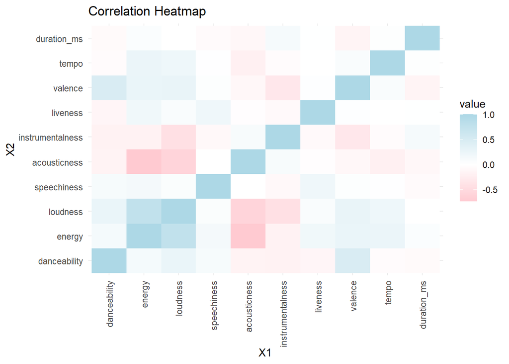

```r
# plot 1, look at correlations between numeric variables
num_vars <- data %>% select(
  danceability,
  energy,
  loudness,
  speechiness,
  acousticness,
  instrumentalness,
  liveness,
  valence,
  tempo,
  duration_ms
)

correlation <- cor(num_vars)
correlation_melt <- melt(correlation)
plot1 <- ggplot(data = correlation_melt) +
  geom_tile(aes(x = X1, y = X2, fill = value)) +
  scale_fill_gradient2(low = "Light Pink", mid = "white", high = "Light Blue", midpoint = 0) +
  theme_minimal() +
  labs(title = "Correlation Heatmap") +
  theme(axis.text.x = element_text(angle = 90, vjust = 0.5, hjust=1))

plot1
```

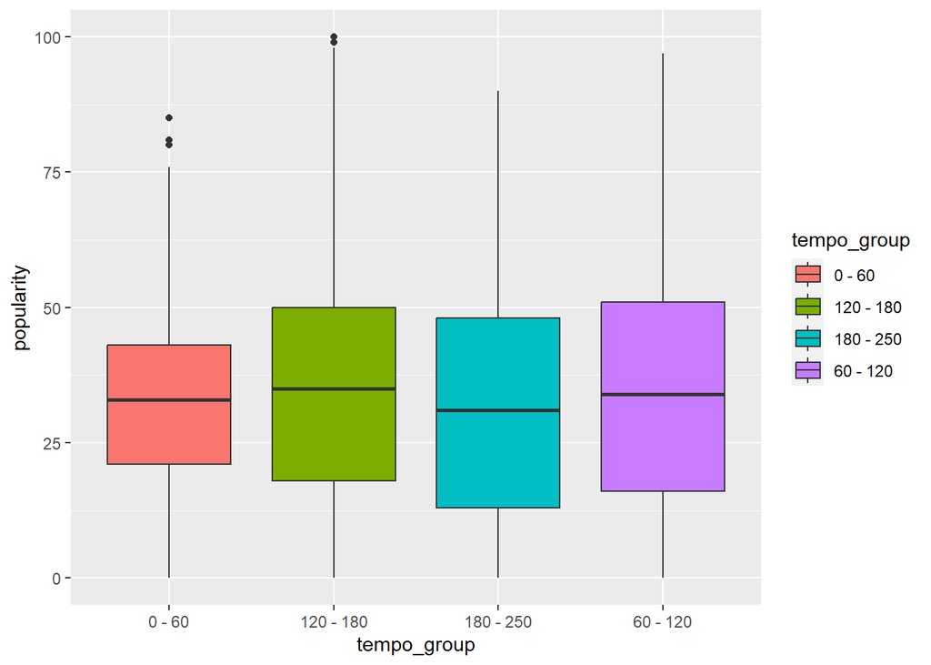

```r
# explore the relationship between tempo and popularity. Would like to explore the distribution of popularity across different genres but there are too many category levels.

data_by_tempo <- data %>%
  mutate(tempo_group = case_when
        (tempo < 60 ~ "0 - 60",
          tempo >= 60 & tempo < 120 ~ "60 - 120",
          tempo >= 120 & tempo < 180 ~ "120 - 180",
          tempo >= 180 & tempo < 250 ~ "180 - 250")) %>%
  group_by(tempo_group)

plot2 <- data_by_tempo %>%
  ggplot(aes(
    x = tempo_group,
    y = popularity,
    fill = tempo_group
  )) +
  geom_boxplot()
plot2
```

## subtasks 2

```r
# data cleaning and filter out popularity > 0
data_edit <- data %>%
  mutate(
  # convert duration in milliseconds to minutes
  duration_min = duration_ms / 60000) %>%
  # removed popularity = 0
  filter(popularity > 0) %>%
  # removed variables that are not applicable for modelling
  select(-duration_ms, -track_name, -album_name, -artists, -track_id, -track_genre, -time_signature, -key)

# convert applicable variables into categorical variables
data_edit$explicit <- as.factor(data_edit$explicit)
data_edit$mode <- as.factor(data_edit$mode)


dim(data_edit)
```

```
## [1] 97980    13
```

```r
data_edit_rows <- nrow(data_edit)
```

The variable `duration_ms` is converted into `duration_mins` millisecond is a very small units and in general, songs duration is in minutes. In addition, after the model selection, any increments in milliseconds are very hard to interpret. All characters variable types are removed as it impact the model selections as they are not categorical variables. `track_genres` were removed as it has too many levels and there are overlap genres such as Pop, Kpop and Jpop. `Time signature` were removed as the song speed is not depend on time signature. `Key` were removed as it is similar to mode variables. Mode has only 2 level factors in contrast to keys. Lastly the number of observations are **97980**

## Subtask 3

*All codes are referenced from STATS 369, Lab4: optimising linear algebra (Bolton, 2023)*

```r
# set seed
set.seed(622)
my_sample <- sample(nrow(data_edit), 20000)
sample_data <- data_edit[my_sample,]
sample_data.df <- data.frame(sample_data)

# cross validation with sample data.
mf <- model.frame(popularity ~., data = sample_data.df)
X <- model.matrix(popularity ~., mf)[,-1]


allyhat <- function(xtrain, ytrain, xtest, lambdas){
  n<-nrow(xtrain)
  yhat<-matrix(nrow=nrow(xtest), ncol=length(lambdas))
  sub<-regsubsets(xtrain, ytrain, method=
                    "back", nvmax = 20)
  summ<-summary(sub)

  for(i in 1:length(lambdas)){
    penMSE<- n*log(summ$rss)+lambdas[i]*(1:20)
    best_p<-which.min(penMSE)
    #lowest AIC
    beta_hat<-coef(sub, best_p)
    #coefficients
    x_in_mod<-cbind(1,xtest)[,summ$which[best_p,]]
    #predictors in that model
    yhat[,i]<-x_in_mod%*%beta_hat
  }
  yhat
}


set.seed(622)
y_sampled = sample_data.df$popularity

n <- nrow(X)
folds<-sample(rep(1:10, length.out = n))
lambdas<-(2:20)[c(T,F)]
fitted<-matrix(nrow= n,ncol=length(lambdas))
for(k in 1:10){
  train<-(1:n)[folds!=k]
  test<-(1:n)[folds==k]
  fitted[test,]<-allyhat(X[train,],y_sampled[train],X[test,], lambdas)
}
mspes <- colMeans((y_sampled-fitted)^2)

mspes
```

```
##  [1] 341.5011 341.4931 341.4684 341.4684 341.4684 341.5463 341.8174 342.0251
##  [9] 342.0225 342.2418
```

```r
which.min(mspes) # so the lambda is 6
```

```
## [1] 3
```

```r
search <- regsubsets(X,y_sampled, nvmax = 20, method = "backward")
summ <- summary(search)
aic <- 500 * log(summ$rss) + 6 *(1:20)
best <- which.min(aic)
betahat <- coef(search, best)
betahat
```

```
##      (Intercept)      speechiness instrumentalness
##         42.31082        -18.72419        -12.27236
```

```r
# Fit model

Xpred <- cbind(1, X)[,summ$which[best,]]
fitted2 <- Xpred %*% betahat
MSPEsample <- sum((y_sampled - fitted2)^2) / length(fitted2)
MSPEsample
```

```
## [1] 349.5261
```

```r
# Fit full model with full data set

mf.full <- model.frame(popularity ~., data = data_edit)
Xfull <- model.matrix(popularity ~., mf.full)[,summ$which[best,]]
y <- data_edit$popularity
fitted = Xfull %*% betahat

MSPEfull <- sum((y - fitted)^2) / length(fitted)
MSPEfull
```

```
## [1] 352.2498
```

Our final model with the lowest AIC is:

$popularity_i = \beta_0 + \beta_1 \times speechiness_i + \beta_2 \times instrumentalness_i + \epsilon_i$

Lastly, I fitted the final model with the full data set, it gives final MSPE of 352.2498122 which is slightly higher than when using the sampled data.

# Task 1.3

```r
# 1) set seed
set.seed(622)


# 2) my song selection
mysong <- data_edit[17,]
knitr::kable(mysong)
```

| popularity | explicit | danceability | energy | loudness | mode | speechiness | acousticness | instrumentalness | liveness | valence | tempo | duration_min |
| --- | --- | --- | --- | --- | --- | --- | --- | --- | --- | --- | --- | --- |
| 56 | FALSE | 0.706 | 0.112 | -18.098 | 1 | 0.0391 | 0.827 | 4e-06 | 0.125 | 0.414 | 110.154 | 2.1625 |

```r
# 3) prediction function
prediction.f <- function(dat, i){
  final_model <- lm(popularity ~ speechiness + instrumentalness, data = data_edit[i,])
  predict(final_model, newdata = mysong) + sample(resid(final_model), 1)
}

# final model, from betahat
final_model <- lm(popularity ~ speechiness + instrumentalness, data = data_edit)

boot2 <- boot(data_edit , prediction.f, R = 1000)

print(boot2)
```

```
##
## ORDINARY NONPARAMETRIC BOOTSTRAP
##
##
## Call:
## boot(data = data_edit, statistic = prediction.f, R = 1000)
##
##
## Bootstrap Statistics :
##     original   bias    std. error
## t1* 20.24416 21.16978    18.69706
```

```r
mean_boot <- mean(boot2$t) - boot2$t0
sd(boot2$t)
```

```
## [1] 18.69706
```

```r
# prediction interval
pi <- boot2$t0 + c(-1.96, 1.96) * sd(boot2$t)
pi
```

```
## [1] -16.40208  56.89041
```

```r
# 4) 1 point prediction
set.seed(622)
pred = predict.lm(object = final_model, newdata = mysong, interval = "none") + sample(resid(final_model), 1)
pred
```

```
##        1
## 31.58615
```

# Task 2: Reflection

I am proud that I stuck through this assignment. It is very hard and very confusing. Code kept crashing, matrix multiplications generating weird warnings but I kept pushing through. I would like to say thank you to all the tutors at the AH. They are all champions. Regardless, of all the warnings and issues, I still have fun. I felt it is almost like a real projects and It was really hand-on assignment.

As for 369 midterm test, I would like to dig through each lines of codes used in this assignment and tried to understand what each variables mean and their functions. In addition. The most challenging part is to understand the concept and memorized all the theories and code that could be examable.

## References

Bolton, L. (2023). Lab 4: optimising linear algebra [Laboratory notes]. University of Auckland. file:///D:/Documents/Uni_UoA/Stats%20369/labs/Lab%204/lab04-optimising-linear-algebra_answer.html

Maharshi Pandya. (2022). 🎹 Spotify Tracks Dataset [Data set]. Kaggle. https://doi.org/10.34740/KAGGLE/DSV/4372070

OpenAI. (2023). ChatGPT (Mar 14 version) [How to generate correlation graph]. https://chat.openai.com/chat